# Analysis of Fandango Movie ratings

Project Goal:

To investigate the integrity of movie ratings on Fandango before and after Walt Hickey’s article in FiveThirthyEight https://fivethirtyeight.com/features/fandango-movies-ratings/. Hickey described an error in the aggregation of Fandango’s scores in comparison to other popular movie rating sites like Rotten Tomatoes and IMDB. Leading to Fandango being much more generous than their counterparts

This project will compare and contrast Fandango’s ratings pre- Hickey’s article (2015) and post-Hickey’s article (2016)

Loading required libraries

```r
library(readr)
library(dplyr)
library(ggplot2)
library(stringr)
library(tidyr)
```

Reading in datasets in of the ratings Hickey used in his analysis and the 16/17 comparison

```r
original_ratings <- read.csv("fandango_score_comparison.csv")
new_ratings <- read.csv("movie_ratings_16_17.csv")
```

Next I’ll drop the columns that are not relevent to our analysis of Fandango

```r
original_ratings <- original_ratings %>%
                select("FILM", "Fandango_Stars", "Fandango_Ratingvalue",
                       "Fandango_votes")
new_ratings <- new_ratings %>%
        select("movie", "year", "fandango")
```

Lets have a quick glimpse of our two dataframes

```r
glimpse(original_ratings)
```

```
Observations: 146
Variables: 4
$ FILM                 <fct> "Avengers: Age of Ultron (2015)", "Cinderella (2015)", "Ant-M...
$ Fandango_Stars       <dbl> 5.0, 5.0, 5.0, 5.0, 3.5, 4.5, 4.0, 4.0, 4.5, 4.5, 4.5, 4.0, 4...
$ Fandango_Ratingvalue <dbl> 4.5, 4.5, 4.5, 4.5, 3.0, 4.0, 3.5, 3.5, 4.0, 4.0, 4.0, 3.5, 3...
$ Fandango_votes       <int> 14846, 12640, 12055, 1793, 1021, 397, 252, 3223, 896, 864, 80...
```

```r
glimpse(new_ratings)
```

```
Observations: 214
Variables: 3
$ movie    <fct> 10 Cloverfield Lane, 13 Hours, A Cure for Wellness, A Dog's Purpose, A Ho...
$ year     <int> 2016, 2016, 2016, 2017, 2016, 2016, 2016, 2016, 2016, 2016, 2016, 2016, 2...
$ fandango <dbl> 3.5, 4.5, 3.0, 4.5, 3.0, 4.0, 4.5, 4.0, 4.0, 3.5, 4.0, 3.5, 4.0, 3.5, 4.0...
```

Few things to note from this;

- We have considerably more rows in the new_ratings dataframe
- The year of release is embedded into the title column for the original_ratings, so we’ll have to do a bit of string manipulation later to pull that out
- We can also see that the Fandango column in the new_ratings dataframe equates to the fandango_Stars in the original_ratings dataframe, so I might quickly change that name so they match up.

Quickly changing the columns names to match both dataframes and satisfy my OCD

```r
new_ratings <- new_ratings %>%
    mutate(Fandango_Stars = fandango,
           fandango = NULL,
           FILM = movie,
           movie = NULL)
glimpse(new_ratings)
```

```
Observations: 214
Variables: 3
$ year           <int> 2016, 2016, 2016, 2017, 2016, 2016, 2016, 2016, 2016, 2016, 2016, 2...
$ Fandango_Stars <dbl> 3.5, 4.5, 3.0, 4.5, 3.0, 4.0, 4.5, 4.0, 4.0, 3.5, 4.0, 3.5, 4.0, 3....
$ FILM           <fct> 10 Cloverfield Lane, 13 Hours, A Cure for Wellness, A Dog's Purpose...
```

In Hickey’s article, he set a minimum of 30 user_votes for a movie to be considered in his analysis, so I’ll use the same figure

```r
sum(original_ratings$Fandango_votes < 30)
```

```
[1] 0
```

```r
summary(original_ratings$Fandango_votes)
```

```
   Min. 1st Qu.  Median    Mean 3rd Qu.    Max.
   35.0   222.2  1446.0  3848.8  4439.5 34846.0
```

Great so we can see we’ve a minimum value of 35, so we’re good to go!

As was mentioed before, we’ll need to get that year out of the of the movie title column

```r
original_ratings <- original_ratings %>%
        mutate(year = str_sub(FILM, -5, -2))
```

Next step is to isolate the films released in 2015 and 2016, as these will be the two we’ll be using in our comparison

```r
movies_15 <- original_ratings %>%
        filter(year == 2015)

movies_16 <- new_ratings %>%
        filter(year == 2016)
```

So now we have out two dataframes with just the information we need to compare their distributions

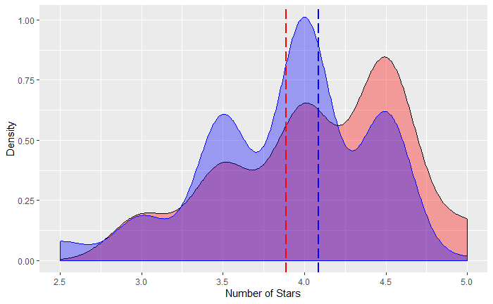

```r
ggplot(data = movies_15, aes(x = Fandango_Stars, fill = year)) +
        geom_density(fill = "red", alpha = 0.35) +
        geom_density(data = movies_16, aes(x = Fandango_Stars), color = "blue",
                     fill = "blue", alpha = 0.35) +
        geom_vline(xintercept = mean(movies_15$Fandango_Stars), color = "blue",
                   lwd = 0.75, linetype = "longdash") +
        geom_vline(xintercept = mean(movies_16$Fandango_Stars), color = "red",
                   lwd = 0.75, linetype = "longdash") +
        labs(x = "Number of Stars", y = "Density") +
        scale_x_continuous(breaks = seq(0,5,0.5)) +
        theme(legend.position = "Top")
```

Few things to note from this * Both years are left-skewed distributions * The mean rating being higher in 2015 than it was in 2016 * Big spike for 4-star ratings in 2016

Time to delve a little deeper in to the data and take a more granular look at it. We’ll do this by generating frequency tables for both years

2015

```r
freq_table_2015 <- movies_15 %>%
                group_by(Fandango_Stars) %>%
                summarise(Absolute_Freq = n()) %>%
                mutate(Percentage = (Absolute_Freq / nrow(movies_15)) * 100)
freq_table_2015
```

| Fandango_Stars | Absolute_Freq | Percentage |
| --- | --- | --- |
| 3.0 | 11 | 8.527132 |
| 3.5 | 23 | 17.829457 |
| 4.0 | 37 | 28.682171 |
| 4.5 | 49 | 37.984496 |
| 5.0 | 9 | 6.976744 |

2016

```r
freq_table_2016 <- movies_16 %>%
                group_by(Fandango_Stars) %>%
                summarise(Absolute_Freq = n()) %>%
                mutate(Percentage = (Absolute_Freq / nrow(movies_15)) * 100)
freq_table_2016
```

| Fandango_Stars | Absolute_Freq | Percentage |
| --- | --- | --- |
| 2.5 | 6 | 4.6511628 |
| 3.0 | 14 | 10.8527132 |
| 3.5 | 46 | 35.6589147 |
| 4.0 | 77 | 59.6899225 |
| 4.5 | 47 | 36.4341085 |
| 5.0 | 1 | 0.7751938 |

FInally we will calculate summary statistics for 2015 and 2016

As there is no built_in mode function in R, this mode function is taken from https://stackoverflow.com/questions/2547402/is-there-a-built-in-function-for-finding-the-mode

```r
mode <- function(x) {
  ux <- unique(x)
  ux[which.max(tabulate(match(x, ux)))]
}
```

Generating the summary statistics

```r
summary_2015 <- movies_15 %>%
                summarise(year = '2015',mean = mean(Fandango_Stars),
                          median = median(Fandango_Stars),
                          mode = mode(Fandango_Stars))
summary_2015
```

| year | mean | median | mode |
| --- | --- | --- | --- |
| 2015 | 4.085271 | 4 | 4.5 |

```r
summary_2016 <- movies_16 %>%
                summarise(year = '2016', mean = mean(Fandango_Stars),
                          median = median(Fandango_Stars),
                          mode = mode(Fandango_Stars))
summary_2016
```

| year | mean | median | mode |
| --- | --- | --- | --- |
| 2016 | 3.887435 | 4 | 4 |

Combining the summary statistics from both years

```r
combined_year_stats <- bind_rows(summary_2015, summary_2016)
```

Pivoting the summary table to make is usable for ggplot

```r
combined_year_stats <- combined_year_stats %>%
    pivot_longer(cols = c(mean, mode, median),
                 values_to = 'value',
                 names_to = 'statistic')
```

Visualizing the differnece in the summary statistics

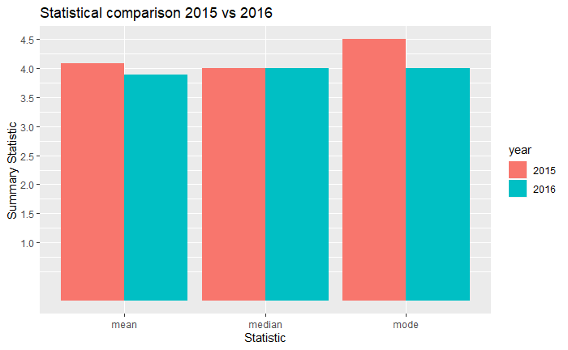

```r
ggplot(data = combined_year_stats, aes(x = statistic, y = value, fill = year)) +
    geom_bar(stat = 'identity',position = 'dodge') +
    labs(y = 'Summary Statistic', x = 'Statistic') +
    ggtitle('Statistical comparison 2015 vs 2016') +
    scale_y_continuous(breaks = seq(1,5,0.5))
```

Conclusions;

- It looks like Fandango did modify their rating slightly in the wake of Walt Hickey’s article in 2015
- We can also see the most common rating awarded in 2015 was 4.5, against 4.0 in 2016. Which suggest that they may hav corrected their rounding up issue that was the reason for their embelished ratings